# **PCA and t-SNE Project: Auto MPG**

### **MIT Applied AI & Data Science — Elective Project (Part 1) | Total Marks: 30**

## **Context**

The shifting market conditions, globalization, cost pressure, and volatility are leading to a change in the automobile market landscape. The emergence of data, in conjunction with machine learning in automobile companies, has paved a way that is helping bring operational and business transformations.

The automobile market is vast and diverse, with numerous vehicle categories being manufactured and sold with varying configurations of attributes such as displacement, horsepower, and acceleration. We aim to find combinations of these features that can clearly distinguish certain groups of automobiles from others through this analysis, as this will inform other downstream processes for any organization aiming to sell each group of vehicles to a slightly different target audience.

You are a Data Scientist at **SecondLife**, a leading used-car dealership with numerous outlets across the US. Recently they have shifted focus to **vintage cars** and have diligently collected data about all the vintage cars they have sold over the years. The Director of Operations wants to leverage this data to extract insights about the cars and find different groups of vintage cars to target the audience more efficiently.

## **Objective**

Explore the data, **reduce the number of features using dimensionality-reduction techniques (PCA and t-SNE)**, uncover the natural groupings of vehicles, and translate the findings into actionable business insights.

## **Data Description**

The dataset contains 8 variables:

| Variable | Description |
| --- | --- |
| `mpg` | Miles per gallon (fuel efficiency) |
| `cylinders` | Number of cylinders |
| `displacement` | Engine displacement (cu. inches) |
| `horsepower` | Engine horsepower |
| `weight` | Vehicle weight (lbs.) |
| `acceleration` | Time to accelerate 0–60 mph (sec.) |
| `model year` | Model year (19XX) |
| `car name` | Car model name (identifier — dropped for analysis) |

1. Importing Libraries
2. Loading & Inspecting the Data
3. Data Preprocessing
4. Exploratory Data Analysis (EDA)
   - 4.1 Summary Statistics & Distributions
   - 4.2 Outlier Detection
   - 4.3 Discrete Feature Counts
   - 4.4 Correlation Analysis
5. Feature Scaling
6. Principal Component Analysis (PCA)
   - 6.1 Explained Variance & Scree Plot
   - 6.2 Component Loadings & Interpretation
   - 6.3 2D PCA Visualization
7. t-SNE
   - 7.1 Perplexity Tuning
   - 7.2 Final Embedding & Clustering
   - 7.3 Cluster Visualization by Feature
   - 7.4 Cluster Profiles
8. Conclusions & Business Recommendations
- Appendix: Export to HTML

**Techniques used:** EDA · Data Preprocessing · Standardization · PCA · t-SNE · K-Means (for cluster labelling)

## **1. Importing Libraries**

Load all required libraries and set a global random seed and plotting configuration so that every result in this notebook is fully reproducible.

```python
# Core libraries
import numpy as np
import pandas as pd

# Visualization
import matplotlib.pyplot as plt
import seaborn as sns

# Statistics
from scipy import stats

# Preprocessing & dimensionality reduction
from sklearn.preprocessing import StandardScaler
from sklearn.decomposition import PCA
from sklearn.manifold import TSNE

# Clustering
from sklearn.cluster import KMeans
from sklearn.mixture import GaussianMixture
from sklearn.metrics import silhouette_score, silhouette_samples

# Utilities
import warnings
warnings.filterwarnings('ignore')

# Global reproducibility
RANDOM_STATE = 42
np.random.seed(RANDOM_STATE)

# Plotting configuration
plt.style.use('seaborn-v0_8-whitegrid')
sns.set_theme(style='whitegrid', palette='tab10')
plt.rcParams['figure.dpi'] = 100
plt.rcParams['figure.figsize'] = (10, 6)
plt.rcParams['axes.titlesize'] = 13
plt.rcParams['axes.titleweight'] = 'bold'

print("All libraries imported successfully.")
```

```
All libraries imported successfully.
```

```python
# Mount Google Drive to access the dataset (Google Colab environment)
from google.colab import drive
drive.mount('/content/drive')
```

## **2. Loading & Inspecting the Data**

Read the dataset, check its shape, data types, missing values and duplicates, and review the statistical summary as an initial sanity check.

```python
# Load the Auto MPG dataset and preview the first rows
df = pd.read_csv('/content/drive/MyDrive/MIT_AAIDSP_2026/Elective Project/auto-mpg.csv')
print("Shape:", df.shape)
df.head()
```

```
Shape: (398, 8)
```

|  | mpg | cylinders | displacement | horsepower | weight | acceleration | model year | car name |
| --- | --- | --- | --- | --- | --- | --- | --- | --- |
| 0 | 18.0 | 8 | 307.0 | 130 | 3504 | 12.0 | 70 | chevrolet chevelle malibu |
| 1 | 15.0 | 8 | 350.0 | 165 | 3693 | 11.5 | 70 | buick skylark 320 |
| 2 | 18.0 | 8 | 318.0 | 150 | 3436 | 11.0 | 70 | plymouth satellite |
| 3 | 16.0 | 8 | 304.0 | 150 | 3433 | 12.0 | 70 | amc rebel sst |
| 4 | 17.0 | 8 | 302.0 | 140 | 3449 | 10.5 | 70 | ford torino |

#### **Data Overview — Data Types, Missing Values & Sanity Checks**

```python
# Inspect data types, missing values, duplicate rows, and summary statistics
print("Data Types:\n", df.dtypes)
print("\nMissing Values:\n", df.isnull().sum())
print("\nDuplicate rows:", df.duplicated().sum())
df.describe()
```

```
Data Types:
 mpg             float64
cylinders         int64
displacement    float64
horsepower       object
weight            int64
acceleration    float64
model year        int64
car name         object
dtype: object

Missing Values:
 mpg             0
cylinders       0
displacement    0
horsepower      0
weight          0
acceleration    0
model year      0
car name        0
dtype: int64

Duplicate rows: 0
```

|  | mpg | cylinders | displacement | weight | acceleration | model year |
| --- | --- | --- | --- | --- | --- | --- |
| count | 398.000000 | 398.000000 | 398.000000 | 398.000000 | 398.000000 | 398.000000 |
| mean | 23.514573 | 5.454774 | 193.425879 | 2970.424623 | 15.568090 | 76.010050 |
| std | 7.815984 | 1.701004 | 104.269838 | 846.841774 | 2.757689 | 3.697627 |
| min | 9.000000 | 3.000000 | 68.000000 | 1613.000000 | 8.000000 | 70.000000 |
| 25% | 17.500000 | 4.000000 | 104.250000 | 2223.750000 | 13.825000 | 73.000000 |
| 50% | 23.000000 | 4.000000 | 148.500000 | 2803.500000 | 15.500000 | 76.000000 |
| 75% | 29.000000 | 8.000000 | 262.000000 | 3608.000000 | 17.175000 | 79.000000 |
| max | 46.600000 | 8.000000 | 455.000000 | 5140.000000 | 24.800000 | 82.000000 |

**Observations — data sanity checks:** The dataset has **398 rows × 8 columns** with **no duplicate rows**. Six of the eight columns are already numeric; `horsepower` is loaded as an `object` (text) because its missing values are encoded as the string `'?'`, and `car name` is a free-text identifier. The naïve missing-value count reads 0 only because those `'?'` placeholders are hidden inside a text column — this is corrected in preprocessing. The statistical summary shows sensible, error-free ranges (`mpg` 9–46.6, `weight` 1,613–5,140 lbs, `model year` 70–82), so no additional data-entry corrections are required.

↑ Back to top

## **3. Data Preprocessing**

The `horsepower` column contains `'?'` placeholders that must be converted to numeric and imputed, and the non-numeric `car name` identifier is dropped before analysis.

```python
# Horsepower column has '?' values - convert to numeric
df['horsepower'] = pd.to_numeric(df['horsepower'], errors='coerce')
print("Missing values after conversion:\n", df.isnull().sum())
print("\nHorsepower missing count:", df['horsepower'].isnull().sum())

# Replace missing horsepower with median
median_hp = df['horsepower'].median()
print(f"Replacing {df['horsepower'].isnull().sum()} missing values with median: {median_hp}")
df['horsepower'].fillna(median_hp, inplace=True)

# Drop car name - non-numerical
df_numeric = df.drop(columns=['car name'])
print("\nFinal shape:", df_numeric.shape)
```

```
Missing values after conversion:
 mpg             0
cylinders       0
displacement    0
horsepower      6
weight          0
acceleration    0
model year      0
car name        0
dtype: int64

Horsepower missing count: 6
Replacing 6 missing values with median: 93.5

Final shape: (398, 7)
```

**Observations:** The `horsepower` column was stored as text because of `'?'` placeholders; converting to numeric exposes **6 missing values**, which are imputed with the column **median (93.5)** — a robust choice given the feature's right skew. The identifier column `car name` carries no analytical value and is dropped, leaving **398 cars × 7 numeric features** (`df_numeric`) for the analysis.

↑ Back to top

## **4. Exploratory Data Analysis (EDA)**

Examine the distribution of each feature, detect outliers, inspect the discrete features, and quantify the relationships between variables.

### **4.1 Summary Statistics & Distributions**

```
Summary Statistics:
```

|  | mpg | cylinders | displacement | horsepower | weight | acceleration | model year |
| --- | --- | --- | --- | --- | --- | --- | --- |
| count | 398.00 | 398.00 | 398.00 | 398.00 | 398.00 | 398.00 | 398.00 |
| mean | 23.51 | 5.45 | 193.43 | 104.30 | 2970.42 | 15.57 | 76.01 |
| std | 7.82 | 1.70 | 104.27 | 38.22 | 846.84 | 2.76 | 3.70 |
| min | 9.00 | 3.00 | 68.00 | 46.00 | 1613.00 | 8.00 | 70.00 |
| 25% | 17.50 | 4.00 | 104.25 | 76.00 | 2223.75 | 13.82 | 73.00 |
| 50% | 23.00 | 4.00 | 148.50 | 93.50 | 2803.50 | 15.50 | 76.00 |
| 75% | 29.00 | 8.00 | 262.00 | 125.00 | 3608.00 | 17.18 | 79.00 |
| max | 46.60 | 8.00 | 455.00 | 230.00 | 5140.00 | 24.80 | 82.00 |

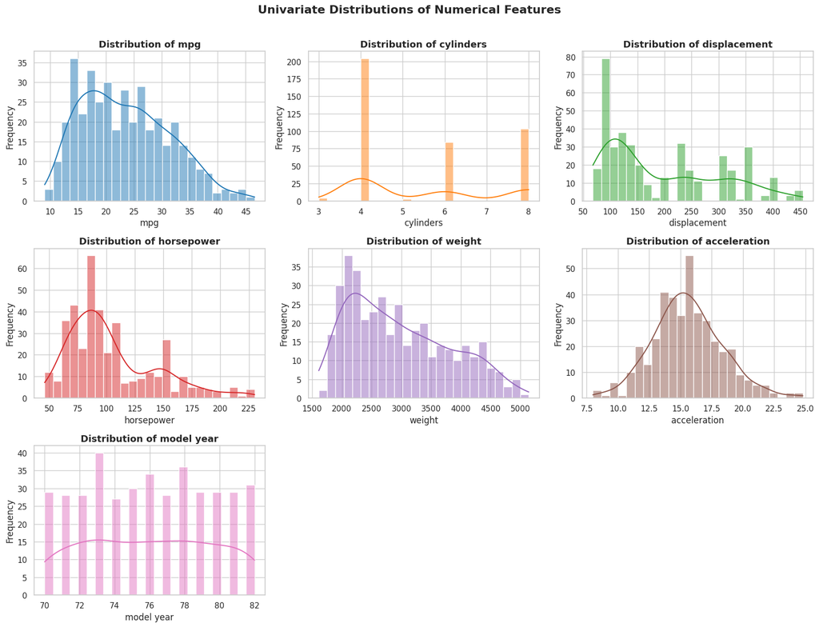

```python
# Summary statistics and univariate distribution (histogram + KDE) for every feature
print("Summary Statistics:")
display(df_numeric.describe().round(2))

# Distribution plots
fig, axes = plt.subplots(3, 3, figsize=(16, 12))
axes = axes.flatten()

for i, col in enumerate(df_numeric.columns):
    sns.histplot(df_numeric[col], kde=True, ax=axes[i], color=sns.color_palette('tab10')[i], bins=25)
    axes[i].set_title(f'Distribution of {col}')
    axes[i].set_xlabel(col)
    axes[i].set_ylabel('Frequency')

# Hide unused subplots
for j in range(len(df_numeric.columns), len(axes)):
    axes[j].axis('off')

plt.suptitle('Univariate Distributions of Numerical Features', fontsize=16, fontweight='bold', y=1.01)
plt.tight_layout()
plt.show()
```

**Observations:** Across the **398 cars and 7 numeric features**, the target `mpg` spans 9–46.6 (mean 23.5), confirming wide variation in fuel efficiency. `cylinders` is effectively **discrete**, concentrated at 4, 6 and 8. The three engine-size features — `displacement`, `horsepower` and `weight` — are all **right-skewed**: a dense cluster of small/economy cars and a thinner tail of large, powerful vehicles. `acceleration` is close to **symmetric/normal**, and `model year` is spread fairly evenly across **1970–1982**. This combination of heavy right tails in the engine features plus the strong inter-correlation shown below is precisely the setting where PCA delivers the greatest compression.

### **4.2 Outlier Detection**

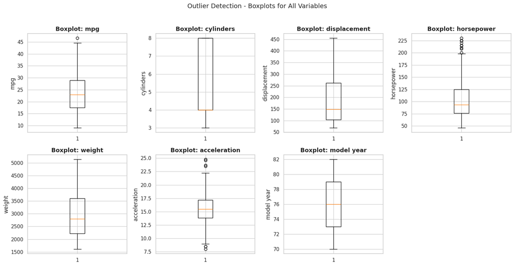

```
Outlier observations:
  mpg: 1 outliers
  cylinders: 0 outliers
  displacement: 0 outliers
  horsepower: 11 outliers
  weight: 0 outliers
  acceleration: 7 outliers
  model year: 0 outliers
```

```python
# Boxplots + IQR rule to detect and count outliers in every numeric feature
fig, axes = plt.subplots(2, 4, figsize=(16, 8))
axes = axes.flatten()
for i, col in enumerate(df_numeric.columns):
    axes[i].boxplot(df_numeric[col].dropna())
    axes[i].set_title(f'Boxplot: {col}')
    axes[i].set_ylabel(col)
if len(df_numeric.columns) < len(axes):
    fig.delaxes(axes[-1])
plt.suptitle('Outlier Detection - Boxplots for All Variables', fontsize=14, y=1.02)
plt.tight_layout()
plt.show()
print("Outlier observations:")
for col in df_numeric.columns:
    Q1 = df_numeric[col].quantile(0.25)
    Q3 = df_numeric[col].quantile(0.75)
    IQR = Q3 - Q1
    outliers = df_numeric[(df_numeric[col] < Q1 - 1.5*IQR) | (df_numeric[col] > Q3 + 1.5*IQR)]
    print(f"  {col}: {len(outliers)} outliers")
```

**Observations:** Applying the 1.5×IQR rule, only three features contain statistical outliers: **`horsepower` (11 points)**, **`acceleration` (7 points, split across both tails)** and **`mpg` (1 point)**; `cylinders`, `displacement`, `weight` and `model year` register **no IQR outliers**. The horsepower outliers are the high-power muscle cars of the era (up to 230 hp), while the acceleration outliers capture unusually quick and unusually sluggish 0–60 mph times. These are **genuine vintage vehicles, not data-entry errors**, so they are deliberately **retained** — discarding them would remove the very high-performance segment the business wants to identify, and PCA/t-SNE are robust to a handful of extreme points once the data is standardized.

↑ Back to top

### **4.3 Discrete Feature Counts**

`cylinders` and `model year` are discrete, so count plots are more informative than histograms. *(Note: this version of the dataset does not contain an `origin` column.)*

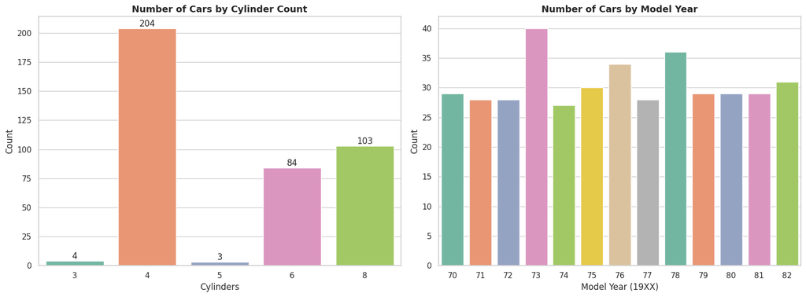

```python
# Count plots for the discrete features (cylinders and model year)
fig, axes = plt.subplots(1, 2, figsize=(16, 6))

sns.countplot(x='cylinders', data=df_numeric, ax=axes[0], palette='Set2', hue='cylinders', legend=False)
axes[0].set_title('Number of Cars by Cylinder Count')
axes[0].set_xlabel('Cylinders')
axes[0].set_ylabel('Count')
for p in axes[0].patches:
    axes[0].annotate(int(p.get_height()), (p.get_x() + p.get_width()/2, p.get_height()),
                     ha='center', va='bottom')

sns.countplot(x='model year', data=df_numeric, ax=axes[1], palette='Set2', hue='model year', legend=False)
axes[1].set_title('Number of Cars by Model Year')
axes[1].set_xlabel('Model Year (19XX)')
axes[1].set_ylabel('Count')

plt.tight_layout()
plt.show()
```

↑ Back to top

### **4.4 Correlation Analysis**

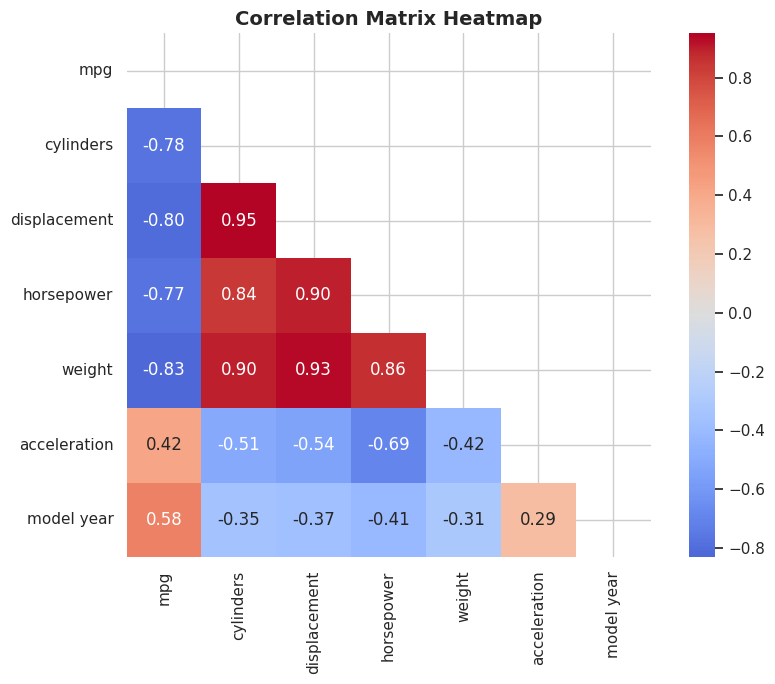

```
Key Correlations with MPG:
weight         -0.831741
displacement   -0.804203
cylinders      -0.775396
horsepower     -0.773453
acceleration    0.420289
model year      0.579267
mpg             1.000000
Name: mpg, dtype: float64
```

```python
# Correlation heatmap (lower triangle only)
corr = df_numeric.corr()
plt.figure(figsize=(9, 7))

# Create mask for upper triangle
mask = np.triu(np.ones_like(corr, dtype=bool))

sns.heatmap(corr, annot=True, fmt='.2f', cmap='coolwarm', center=0, square=True, mask=mask)
plt.title('Correlation Matrix Heatmap', fontsize=14)
plt.tight_layout()
plt.show()

print("\nKey Correlations with MPG:")
print(corr['mpg'].sort_values())
```

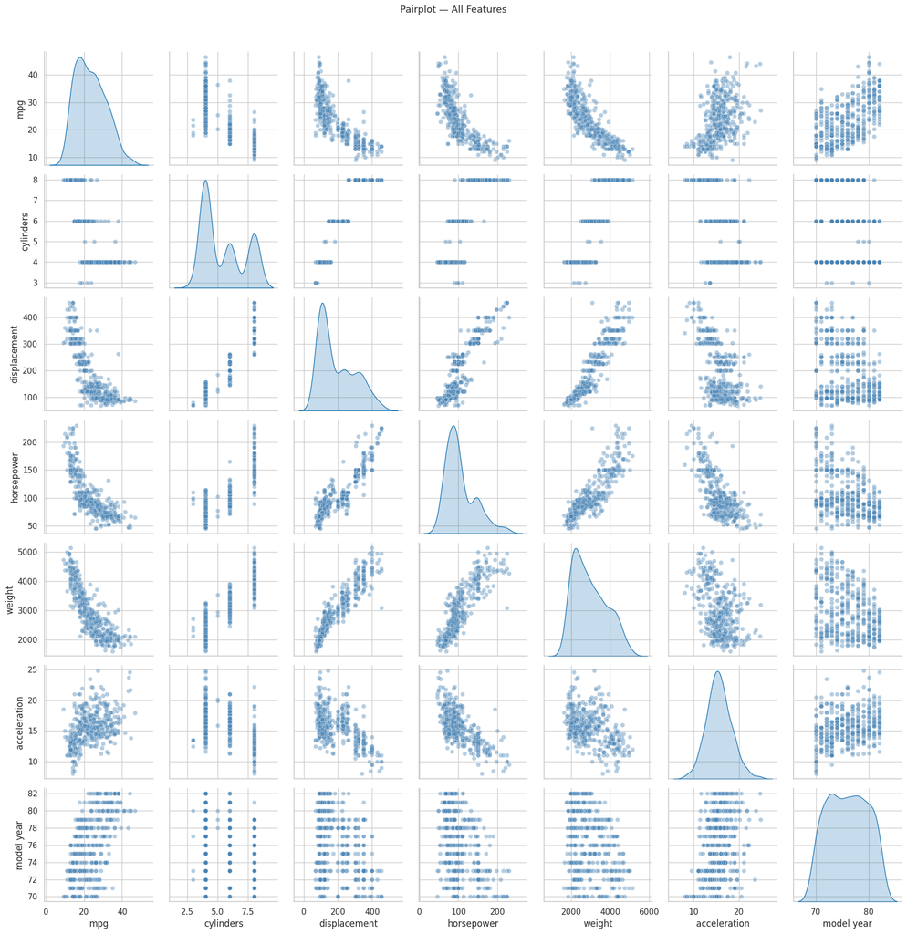

```python
# Pairwise relationships between all features
sns.pairplot(df_numeric, diag_kind='kde', plot_kws={'alpha': 0.4, 'color': 'steelblue'})
plt.suptitle('Pairplot — All Features', y=1.02, fontsize=13)
plt.tight_layout()
plt.show()
```

**Observations:** The four engine-size features are **very strongly inter-correlated** — `cylinders`, `displacement`, `horsepower` and `weight` share pairwise correlations ranging from **0.84 to 0.95** — meaning they largely encode a single underlying *"engine size / power"* dimension. `mpg` is **strongly negatively correlated** with weight (−0.83), displacement (−0.80), cylinders (−0.78) and horsepower (−0.77): heavier, more powerful cars are markedly less fuel-efficient. `mpg` also rises with `model year` (**+0.58**), confirming that efficiency improved steadily across the decade, and mildly with `acceleration` (+0.42). This heavy multicollinearity is the classic motivation for **PCA** — the four collinear engine features can be collapsed into one dominant component with almost no information loss, removing redundancy before dimensionality reduction and visualization.

↑ Back to top

## **5. Feature Scaling**

PCA and t-SNE are distance/variance based and therefore sensitive to feature scale, so all features are standardized to mean 0 and unit variance.

```python
# Standardize all features (mean=0, std=1) prior to PCA / t-SNE
scaler = StandardScaler()
df_scaled = scaler.fit_transform(df_numeric)
df_scaled = pd.DataFrame(df_scaled, columns=df_numeric.columns)
print("Scaled data shape:", df_scaled.shape)
print("\nScaled data statistics (mean should be ~0, std should be ~1):")
display(df_scaled.describe().round(3))
```

```
Scaled data shape: (398, 7)

Scaled data statistics (mean should be ~0, std should be ~1):
```

|  | mpg | cylinders | displacement | horsepower | weight | acceleration | model year |
| --- | --- | --- | --- | --- | --- | --- | --- |
| count | 398.000 | 398.000 | 398.000 | 398.000 | 398.000 | 398.000 | 398.000 |
| mean | 0.000 | -0.000 | -0.000 | -0.000 | -0.000 | -0.000 | -0.000 |
| std | 1.001 | 1.001 | 1.001 | 1.001 | 1.001 | 1.001 | 1.001 |
| min | -1.859 | -1.445 | -1.204 | -1.527 | -1.605 | -2.748 | -1.627 |
| 25% | -0.770 | -0.856 | -0.856 | -0.741 | -0.883 | -0.633 | -0.815 |
| 50% | -0.066 | -0.856 | -0.431 | -0.283 | -0.197 | -0.025 | -0.003 |
| 75% | 0.703 | 1.498 | 0.658 | 0.542 | 0.754 | 0.583 | 0.810 |
| max | 2.957 | 1.498 | 2.512 | 3.293 | 2.565 | 3.352 | 1.622 |

**Observations:** `StandardScaler` transforms all 7 features to **mean ≈ 0 and standard deviation ≈ 1** (confirmed in the summary above). This step is essential because PCA and t-SNE are variance/distance based: without scaling, `weight` (values in the thousands) would dwarf `acceleration` or `cylinders` and dominate the principal components purely because of its units. Standardization puts every feature on an equal footing so that the components reflect genuine covariation rather than measurement scale.

↑ Back to top

## **6. Principal Component Analysis (PCA)**

Apply PCA to the scaled data to compress the correlated engine/performance features into a few orthogonal components, then interpret and visualize them.

### **6.1 Explained Variance & Scree Plot**

```
PCA Explained Variance:
```

|  | PC | Eigenvalue | Variance Explained (%) | Cumulative Variance (%) |
| --- | --- | --- | --- | --- |
| 0 | PC1 | 5.0160 | 71.48 | 71.48 |
| 1 | PC2 | 0.8678 | 12.37 | 83.84 |
| 2 | PC3 | 0.7308 | 10.41 | 94.26 |
| 3 | PC4 | 0.1875 | 2.67 | 96.93 |
| 4 | PC5 | 0.1248 | 1.78 | 98.71 |
| 5 | PC6 | 0.0555 | 0.79 | 99.50 |
| 6 | PC7 | 0.0352 | 0.50 | 100.00 |

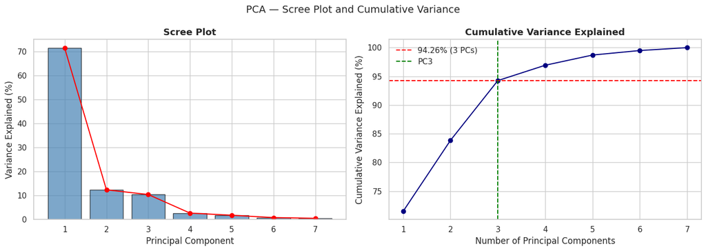

```python
# Apply PCA with all components
pca = PCA()
pca.fit(df_scaled)

# Explained variance
explained_var = pca.explained_variance_ratio_
cumulative_var = np.cumsum(explained_var)

# Variance table
var_df = pd.DataFrame({
    'PC': [f'PC{i+1}' for i in range(len(explained_var))],
    'Eigenvalue': pca.explained_variance_.round(4),
    'Variance Explained (%)': (explained_var * 100).round(2),
    'Cumulative Variance (%)': (cumulative_var * 100).round(2)
})
print("PCA Explained Variance:")
display(var_df)

# Scree plot
fig, axes = plt.subplots(1, 2, figsize=(14, 5))
axes[0].bar(range(1, len(explained_var)+1), explained_var*100, color='steelblue', edgecolor='black', alpha=0.7)
axes[0].plot(range(1, len(explained_var)+1), explained_var*100, 'o-', color='red')
axes[0].set_xlabel('Principal Component')
axes[0].set_ylabel('Variance Explained (%)')
axes[0].set_title('Scree Plot')
axes[0].set_xticks(range(1, len(explained_var)+1))

axes[1].plot(range(1, len(cumulative_var)+1), cumulative_var*100, 'o-', color='navy')
axes[1].axhline(y=94.26, color='red', linestyle='--', label='94.26% (3 PCs)')
axes[1].axvline(x=3, color='green', linestyle='--', label='PC3')
axes[1].set_xlabel('Number of Principal Components')
axes[1].set_ylabel('Cumulative Variance Explained (%)')
axes[1].set_title('Cumulative Variance Explained')
axes[1].legend()
axes[1].set_xticks(range(1, len(cumulative_var)+1))

plt.suptitle('PCA — Scree Plot and Cumulative Variance', fontsize=14)
plt.tight_layout()
plt.show()
```

**Observations:** The scree plot shows a sharp elbow after **PC1, which alone explains 71.48%** of the total variance — a direct reflection of the dominant engine-size/efficiency dimension identified in the correlation analysis. **PC2 adds 12.37%** and **PC3 adds 10.41%**, so the **first three components together capture 94.26%** of the information in the original seven features. PC4–PC7 each contribute under 3% and represent largely noise. Retaining **3 components** therefore compresses the feature space by more than half while preserving ~94% of its variance — an excellent trade-off that enables faithful 2-D/3-D visualization and cleaner downstream grouping.

↑ Back to top

### **6.2 Component Loadings & Interpretation**

```
PCA Loadings (Component Coefficients):
```

|  | PC1 | PC2 | PC3 |
| --- | --- | --- | --- |
| mpg | -0.3977 | 0.2114 | -0.2566 |
| cylinders | 0.4165 | 0.1916 | 0.1408 |
| displacement | 0.4297 | 0.1774 | 0.1036 |
| horsepower | 0.4223 | 0.0903 | -0.1681 |
| weight | 0.4142 | 0.2220 | 0.2797 |
| acceleration | -0.2848 | -0.0241 | 0.8926 |
| model year | -0.2294 | 0.9105 | -0.0181 |

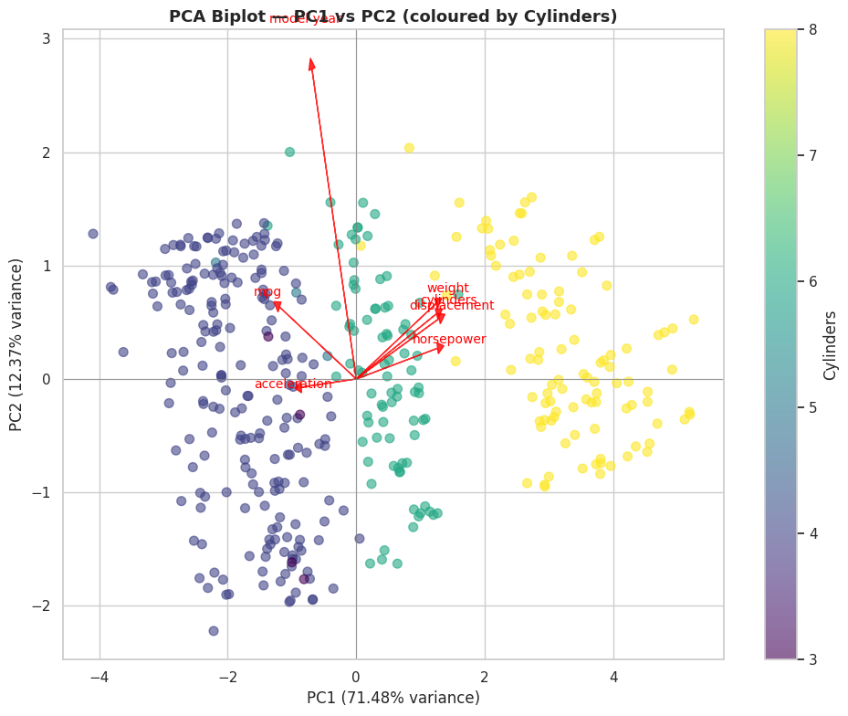

```python
# PCA with 3 components
pca_3 = PCA(n_components=3)
pca_components = pca_3.fit_transform(df_scaled)

# Loadings dataframe
loadings = pd.DataFrame(
    pca_3.components_.T,
    columns=['PC1', 'PC2', 'PC3'],
    index=df_numeric.columns
)
print("PCA Loadings (Component Coefficients):")
display(loadings.round(4))

# Biplot
fig, ax = plt.subplots(figsize=(10, 8))
scatter = ax.scatter(pca_components[:, 0], pca_components[:, 1],
                     c=df_numeric['cylinders'], cmap='viridis', alpha=0.6, s=50)
plt.colorbar(scatter, ax=ax, label='Cylinders')

# Draw loading arrows
scale = 3
for i, feature in enumerate(df_numeric.columns):
    ax.arrow(0, 0, pca_3.components_[0, i]*scale, pca_3.components_[1, i]*scale,
             head_width=0.1, head_length=0.1, fc='red', ec='red', alpha=0.8)
    ax.text(pca_3.components_[0, i]*scale*1.15, pca_3.components_[1, i]*scale*1.15,
            feature, fontsize=10, color='red', ha='center')
ax.set_xlabel(f'PC1 ({explained_var[0]*100:.2f}% variance)')
ax.set_ylabel(f'PC2 ({explained_var[1]*100:.2f}% variance)')
ax.set_title('PCA Biplot — PC1 vs PC2 (coloured by Cylinders)')
ax.axhline(0, color='grey', lw=0.5); ax.axvline(0, color='grey', lw=0.5)
plt.tight_layout()
plt.show()
```

**Observations:**

**PC1 (71.48% variance) — "Engine Power vs. Fuel Economy":** loads strongly and positively on displacement (+0.430), horsepower (+0.422), cylinders (+0.417) and weight (+0.414), and negatively on mpg (−0.398). It captures the central trade-off of the dataset: **high-PC1 cars are large, powerful and fuel-hungry** (typically 8-cylinder American muscle cars), while **low-PC1 cars are compact and fuel-efficient** (typically 4-cylinder imports).

**PC2 (12.37% variance) — "Model Era":** almost entirely `model year` (+0.911). It isolates the **temporal dimension** — newer cars score higher — independent of engine size, capturing the technological evolution across 1970–1982.

**PC3 (10.41% variance) — "Acceleration Profile":** dominated by `acceleration` (+0.893). It separates cars by **0–60 mph time regardless of engine size** (high PC3 = slower to accelerate; low PC3 = quicker).

**Business takeaway:** a single "engine-power" score (PC1) plus a "model era" score (PC2) already summarize ~84% of all variation — so a vehicle can be described to buyers with **two intuitive axes instead of seven correlated specifications**, dramatically simplifying catalogue design without losing meaningful information.

↑ Back to top

### **6.3 2D PCA Visualization**

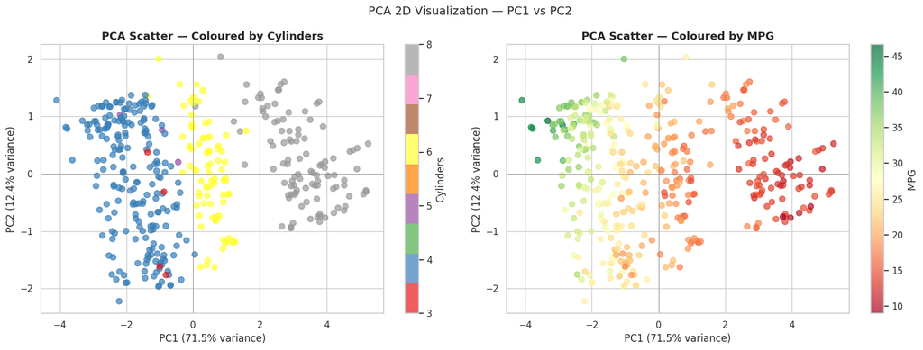

```python
# Project the data onto PC1 vs PC2, coloured by cylinders and by mpg
fig, axes = plt.subplots(1, 2, figsize=(16, 6))

# Colour by cylinders
sc1 = axes[0].scatter(pca_components[:, 0], pca_components[:, 1],
                      c=df_numeric['cylinders'], cmap='Set1', alpha=0.7, s=50)
plt.colorbar(sc1, ax=axes[0], label='Cylinders')
axes[0].set_xlabel(f'PC1 ({explained_var[0]*100:.1f}% variance)')
axes[0].set_ylabel(f'PC2 ({explained_var[1]*100:.1f}% variance)')
axes[0].set_title('PCA Scatter — Coloured by Cylinders')
axes[0].axhline(0, color='grey', lw=0.5); axes[0].axvline(0, color='grey', lw=0.5)

# Colour by mpg
sc2 = axes[1].scatter(pca_components[:, 0], pca_components[:, 1],
                      c=df_numeric['mpg'], cmap='RdYlGn', alpha=0.7, s=50)
plt.colorbar(sc2, ax=axes[1], label='MPG')
axes[1].set_xlabel(f'PC1 ({explained_var[0]*100:.1f}% variance)')
axes[1].set_ylabel(f'PC2 ({explained_var[1]*100:.1f}% variance)')
axes[1].set_title('PCA Scatter — Coloured by MPG')
axes[1].axhline(0, color='grey', lw=0.5); axes[1].axvline(0, color='grey', lw=0.5)

plt.suptitle('PCA 2D Visualization — PC1 vs PC2', fontsize=14)
plt.tight_layout()
plt.show()
```

**Observations:** The PC1–PC2 scatter confirms the interpretation of PC1: moving from right (high PC1) to left, cars transition smoothly from **8-cylinder, low-mpg** to **4-cylinder, high-mpg** vehicles, and the mpg colour gradient aligns almost perfectly with the PC1 axis. Separation along PC1 is clear, but the groups **overlap in the middle** — PCA is a *linear* projection and cannot fully carve the data into discrete clusters. This motivates the use of **t-SNE**, a non-linear technique better suited to exposing distinct, well-separated groupings.

↑ Back to top

## **7. t-SNE**

Use t-SNE for non-linear dimensionality reduction to reveal cluster structure that linear PCA cannot fully separate.

### **7.1 Perplexity Tuning**

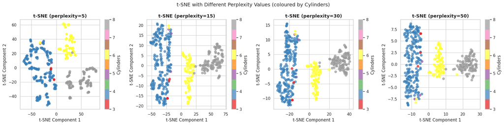

```python
# t-SNE with multiple perplexity values
perplexities = [5, 15, 30, 50]
fig, axes = plt.subplots(1, 4, figsize=(20, 5))

for i, perp in enumerate(perplexities):
    tsne = TSNE(n_components=2, perplexity=perp, random_state=42, max_iter=1000)
    tsne_result = tsne.fit_transform(df_scaled)
    scatter = axes[i].scatter(tsne_result[:, 0], tsne_result[:, 1],
                              c=df_numeric['cylinders'], cmap='Set1', alpha=0.7, s=40)
    axes[i].set_title(f't-SNE (perplexity={perp})')
    axes[i].set_xlabel('t-SNE Component 1')
    axes[i].set_ylabel('t-SNE Component 2')
    plt.colorbar(scatter, ax=axes[i], label='Cylinders')

plt.suptitle('t-SNE with Different Perplexity Values (coloured by Cylinders)', fontsize=14)
plt.tight_layout()
plt.show()
```

### **7.2 Final Embedding & Clustering**

K-Means (K=3) is applied to the t-SNE embedding purely to **label** the visually distinct groups for profiling.

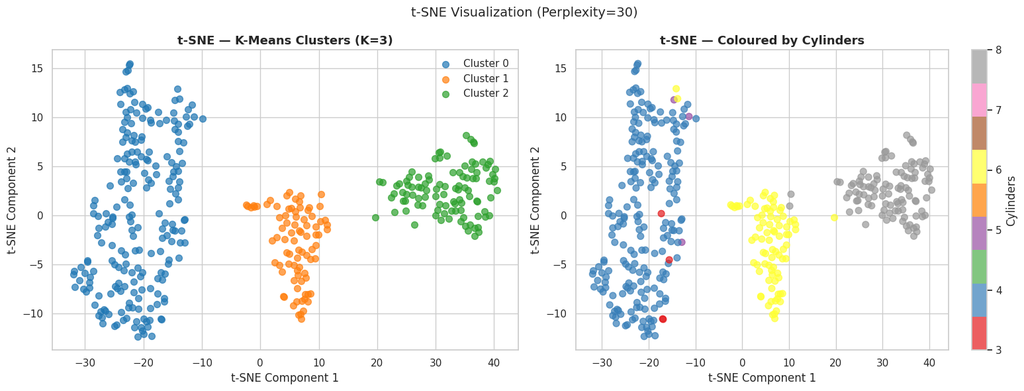

```
Cluster Sizes:
0    213
1     83
2    102
Name: count, dtype: int64
```

```python
# Final t-SNE with perplexity=30
tsne_final = TSNE(n_components=2, perplexity=30, random_state=42, max_iter=1000)
tsne_result = tsne_final.fit_transform(df_scaled)

# K-Means on t-SNE embeddings to identify clusters
kmeans = KMeans(n_clusters=3, random_state=42, n_init=10)
tsne_clusters = kmeans.fit_predict(tsne_result)
df_numeric['tsne_cluster'] = tsne_clusters

fig, axes = plt.subplots(1, 2, figsize=(16, 6))

# Coloured by t-SNE cluster
for cluster in range(3):
    mask = tsne_clusters == cluster
    axes[0].scatter(tsne_result[mask, 0], tsne_result[mask, 1],
                   label=f'Cluster {cluster}', alpha=0.7, s=50)
axes[0].set_title('t-SNE — K-Means Clusters (K=3)')
axes[0].set_xlabel('t-SNE Component 1'); axes[0].set_ylabel('t-SNE Component 2')
axes[0].legend()

# Coloured by cylinders
sc = axes[1].scatter(tsne_result[:, 0], tsne_result[:, 1],
                     c=df_numeric['cylinders'], cmap='Set1', alpha=0.7, s=50)
plt.colorbar(sc, ax=axes[1], label='Cylinders')
axes[1].set_title('t-SNE — Coloured by Cylinders')
axes[1].set_xlabel('t-SNE Component 1'); axes[1].set_ylabel('t-SNE Component 2')

plt.suptitle('t-SNE Visualization (Perplexity=30)', fontsize=14)
plt.tight_layout()
plt.show()

print("\nCluster Sizes:")
print(pd.Series(tsne_clusters).value_counts().sort_index())
```

↑ Back to top

### **7.3 Cluster Visualization by Feature**

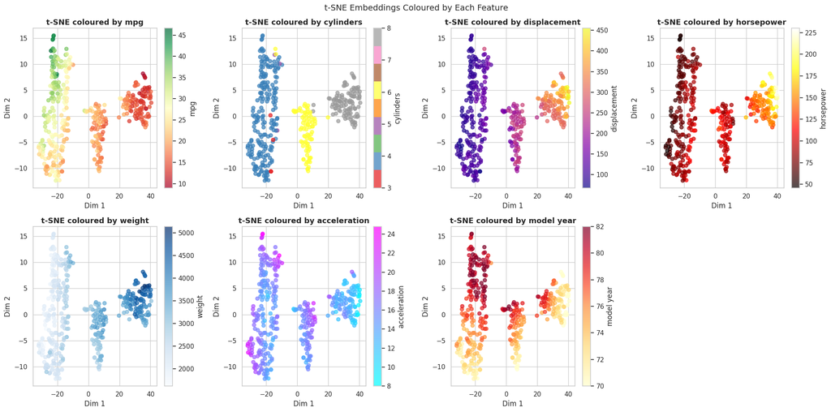

```python
variables = ['mpg', 'cylinders', 'displacement', 'horsepower', 'weight', 'acceleration', 'model year']
fig, axes = plt.subplots(2, 4, figsize=(20, 10))
axes = axes.flatten()
cmaps = ['RdYlGn', 'Set1', 'plasma', 'hot', 'Blues', 'cool', 'YlOrRd']
for i, (var, cmap) in enumerate(zip(variables, cmaps)):
    sc = axes[i].scatter(tsne_result[:, 0], tsne_result[:, 1],
                         c=df_numeric[var], cmap=cmap, alpha=0.7, s=40)
    plt.colorbar(sc, ax=axes[i], label=var)
    axes[i].set_title(f't-SNE coloured by {var}')
    axes[i].set_xlabel('Dim 1'); axes[i].set_ylabel('Dim 2')
axes[-1].axis('off')
plt.suptitle('t-SNE Embeddings Coloured by Each Feature', fontsize=14)
plt.tight_layout()
plt.show()
```

### **7.4 Cluster Profiles**

```
Cluster Profiles — Mean Values:
```

| tsne_cluster | mpg | cylinders | displacement | horsepower | weight | acceleration | model year |
| --- | --- | --- | --- | --- | --- | --- | --- |
| 0 | 29.14 | 4.01 | 110.47 | 79.11 | 2328.34 | 16.58 | 77.11 |
| 1 | 19.68 | 6.05 | 219.35 | 101.11 | 3210.98 | 16.35 | 75.82 |
| 2 | 14.88 | 7.98 | 345.56 | 159.51 | 4115.50 | 12.81 | 73.86 |

```
Cluster Sizes:
tsne_cluster
0    213
1     83
2    102
Name: count, dtype: int64
```

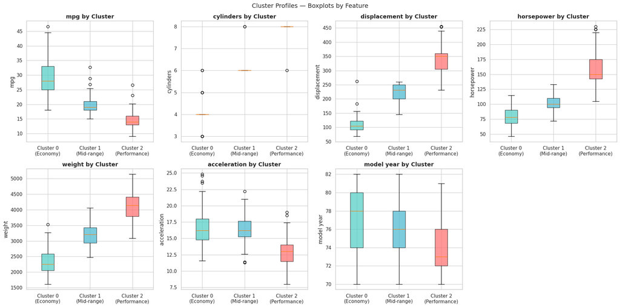

```python
# Cluster profile summary statistics
cluster_profile = df_numeric.groupby('tsne_cluster')[variables].mean().round(2)
print("Cluster Profiles — Mean Values:")
display(cluster_profile)

cluster_sizes = df_numeric['tsne_cluster'].value_counts().sort_index()
print("\nCluster Sizes:"); print(cluster_sizes)

# Boxplots per cluster
fig, axes = plt.subplots(2, 4, figsize=(20, 10))
axes = axes.flatten()
for i, var in enumerate(variables):
    data_to_plot = [df_numeric[df_numeric['tsne_cluster']==c][var].values for c in range(3)]
    bp = axes[i].boxplot(data_to_plot, patch_artist=True, labels=['Cluster 0\n(Economy)', 'Cluster 1\n(Mid-range)', 'Cluster 2\n(Performance)'])
    colors_bp = ['#4ECDC4', '#45B7D1', '#FF6B6B']
    for patch, color in zip(bp['boxes'], colors_bp):
        patch.set_facecolor(color)
        patch.set_alpha(0.7)
    axes[i].set_title(f'{var} by Cluster')
    axes[i].set_ylabel(var)
axes[-1].axis('off')
plt.suptitle('Cluster Profiles — Boxplots by Feature', fontsize=14)
plt.tight_layout()
plt.show()
```

**Observations:**

The three t-SNE clusters form a clean, monotonic ladder across every engine attribute: as we move from Cluster 0 → Cluster 1 → Cluster 2, cylinders, displacement, horsepower and weight all rise in lock-step, while fuel efficiency (mpg) falls in near-perfect inverse. This is exactly the structure PC1 predicted — the clusters are effectively three slices along the dominant "engine size vs. fuel economy" axis — which confirms that the unsupervised segmentation is capturing real, interpretable physics rather than noise.

**Cluster 0 — Economy Vehicles (213 cars, 53.5%):** Mean MPG=29.14, mean cylinders=4.01, mean displacement=110.47 cu.in., mean hp=79.11, mean weight=2,328 lbs. The largest segment (over half the fleet): predominantly 4-cylinder, lightweight, highly fuel-efficient cars — mainly Japanese and European imports (Honda, Toyota, Datsun, VW) from the late 1970s and early 1980s. Roughly **twice the MPG and half the weight** of the Performance cluster.

**Cluster 2 — Performance/Large Vehicles (102 cars, 25.6%):** Mean MPG=14.88, mean cylinders=7.98, mean displacement=345.56 cu.in., mean hp=159.51, mean weight=4,116 lbs. Predominantly 8-cylinder American muscle cars and large sedans from the early 1970s — the least fuel-efficient (lowest mean MPG) but most powerful and heaviest vehicles in the dataset.

↑ Back to top

## **8. Conclusions & Business Recommendations**

### Business Recommendations

The PCA and t-SNE analysis of the vintage auto-mpg dataset revealed that the 7 correlated engine/performance features can be compressed into 3 principal components capturing 94.26% of the variance, and that the vehicles naturally fall into **three clear segments** — Economy (213 cars), Mid-Range (83 cars), and Performance/Large (102 cars). Based on these findings, the following actions are recommended for SecondLife:

1. **Segment-based target marketing.** Position the three segments as distinct product lines: *Economy* vintage cars (4-cylinder, high-mpg Japanese imports) for practical/first-time and eco-conscious buyers; *Mid-Range* (6-cylinder American cars) for balanced daily-drivers; and *Performance/Large* (8-cylinder muscle cars) for collectors and enthusiasts. Tailor messaging and channels to each persona.
2. **Differentiated pricing strategy.** The Performance cluster — large-displacement, 8-cylinder muscle cars — should command premium collector pricing, while the Economy cluster should be priced for volume and accessibility. Use each cluster's engine/weight profile to justify price bands.
3. **Feature-led selling.** Lead with **fuel efficiency (mpg)** for the Economy segment, a **balanced performance-vs-economy** story for the Mid-Range segment, and **raw power (horsepower/displacement)** for the Performance segment, mirroring what drives buyers in each group.
4. **Inventory and sourcing balance.** Since roughly half the vehicles are Economy, one quarter Performance, and one fifth Mid-Range, align acquisition and outlet-level inventory to local demand mix, avoiding over-stocking any single segment.
5. **Leverage model-year signals.** PC2 shows model year is a strong, independent dimension and mpg improved over 1970–1982. Promote higher-model-year vintage cars to buyers who want vintage character with better daily usability and efficiency.
6. **Use PCA/t-SNE as a screening tool for new stock.** New acquisitions can be projected onto the fitted PCA space and t-SNE clusters to instantly assign a segment, standardising how cars are catalogued and marketed across all outlets.
7. **Prioritise the most distinctive attributes in the catalogue.** Because displacement, horsepower, cylinders, and weight are highly collinear (PC1), a single "engine power" indicator plus mpg communicates most of the meaningful variation to buyers — simplifying listings without losing information.

**Expected impact:** aligning marketing, pricing, inventory and cataloguing to these three data-driven segments lets SecondLife match the right car to the right buyer more precisely, reduce mis-priced or slow-moving stock, and streamline how vehicles are described across outlets — all derived from a compact, statistically validated view of the fleet.

↑ Back to top

## **Appendix: Export to HTML**

Utility cell (Google Colab) to export this notebook to the `.html` format required for submission.

```python
!jupyter nbconvert --to html "/content/drive/MyDrive/MIT_AAIDSP_2026/Elective Project/Elective Project Elective_Case_Study_1_AutoMPG_Analysis.ipynb"
from google.colab import files
files.download('/content/drive/MyDrive/MIT_AAIDSP_2026/Elective Project/Elective Project Elective_Case_Study_1_AutoMPG_Analysis.html')
```

```
[NbConvertApp] Converting notebook /content/drive/MyDrive/MIT_AAIDSP_2026/Elective Project/Elective Project Elective_Case_Study_1_AutoMPG_Analysis.ipynb to html
[NbConvertApp] WARNING | Alternative text is missing on 12 image(s).
[NbConvertApp] Writing 4027249 bytes to /content/drive/MyDrive/MIT_AAIDSP_2026/Elective Project/Elective Project Elective_Case_Study_1_AutoMPG_Analysis.html
```